# Causality and Instrumental Variables

73-374 Econometrics II

## Causality

- Want to know causal effect of $X$ on $Y$
  - How does education affect wages?
  - How does changing the price you charge affect how much your customers buy?
  - How does sentencing affect crime?

## Causal Models

- Data comes from a world where some variables cause other variables
- We describe these relationships by a **structural model**
  - Potential outcomes, structural equations, or causal graphs
- In some cases, observed data allows us to learn information about (parameters of) causal model
- Last classes: 2 cases where regression can be used to find causal effects
  - Experiments
  - Control
- Today
  - When can we use control?
  - What to do when control not possible?

## Control: Review

- In situations where control is useful, $X$ determined by $W$, with all other variation in $X$ random ($Y^x\perp X|W$)
- Causal effect of $X$ on $Y$ given by adjustment formula
  $$E(Y|do(X))=\int E(Y|X,W)P(W)dW$$
- Linear model for $E[Y|X,W]$
  $$Y =\beta_0 +\beta_{1}X +\beta_{2}W + U$$
  - Correct specification of $E[Y|X,W]$ means $E[U|X,W]=0$
    - (Mean) independence of residual
  - $\beta_1$ gives average treatment effect (ATE) of $X$

## d-separation in general graphs

- Want rules for arbitrary graphs describing when control is sufficient to recover causal effect
  - First, define rule describing what conditioning implies for independence
- When does conditioning on set of nodes $W$ imply for two disjoint sets of nodes $X$ $Y$ that $X\perp Y|W$?
- We say a (non-directed) path from $X_i$ to $Y_j$ is **blocked** by $W$ if it contains either
  - A collider which is *not* in $W$ and of which $W$ is *not* a descendant
  - A non-collider which *is* in $W$
- We say $X$ and $Y$ are **d-separated** (by $W$) if all paths between $X$ and $Y$ are blocked
- **Theorem** (Pearl, 2009)
  - $X\perp Y|W$ if and only if $X$ and $Y$ are d-separated by $W$

## Backdoor Criterion

- Using d-separation, can define a complete criterion for when control recovers $P(Y|do(X=x))$
- A set of variables $W$ satisfies **Backdoor Criterion** between $X$ and $Y$ if
  - No node in $W$ is a descendant of $X$
  - $W$ blocks every path between $X$ and $Y$ that contains an edge directed into $X$
- **Theorem** (Pearl, 2009): If $W$ satisfies the backdoor criterion between $X$ and $Y$, the adjustment formula recovers the causal effect of $X$ on $Y$
  $$P(Y|do(X=x))=\int Pr(Y|W,X=x)Pr(W)dw$$

## Backdoor criterion, intuition (Code)

```r
library(dagitty) #Library to create and analyze causal graphs
library(ggdag) #library to plot causal graphs
```

```r
#Check if W satisfies criterion
isAdjustmentSet(graphname,"W",exposure="X",outcome="Y")
#Find variables that satisfy criterion, if they exist
adjustmentSets(graphname,exposure="X",outcome="Y")
```

## Backdoor criterion, intuition

- Blocking path component ensures that adjustment variables account for confounding by causes other than the cause of interest and do not introduce additional bias by inducing new correlations through colliders
- Non-descendant component avoids “bad controls” which are themselves affected by treatment
- I will not force you to recall exact definition of d-separation or backdoor criterion
- Point is that given a causal story, systematic method can recover whether control is sufficient
  - In `dagitty`, check backdoor criterion between $X$ and $Y$ by

```r
#Check if W satisfies criterion
isAdjustmentSet(graphname,"W",exposure="X",outcome="Y")
#Find variables that satisfy criterion, if they exist
adjustmentSets(graphname,exposure="X",outcome="Y")
```

## Example: finding adjustment sets (Code)

```r
complicatedgraph<-dagify(Y~A+C,B~X+Y,A~X,X~C,D~B) #create graph
#Set position of nodes
coords<-list(x=c(X = 0, A = 1, B = 1, C=1, Y=2, D=2),
     y=c(X = 0, A = 0.1, B=0, C=-0.1, Y = 0, D=0.1))
coords_df<-coords2df(coords)
coordinates(complicatedgraph)<-coords2list(coords_df)

#Plot causal graph
ggdag(complicatedgraph)+theme_dag_blank()
  +labs(title="Complicated Graph")
```

## Example: finding adjustment sets

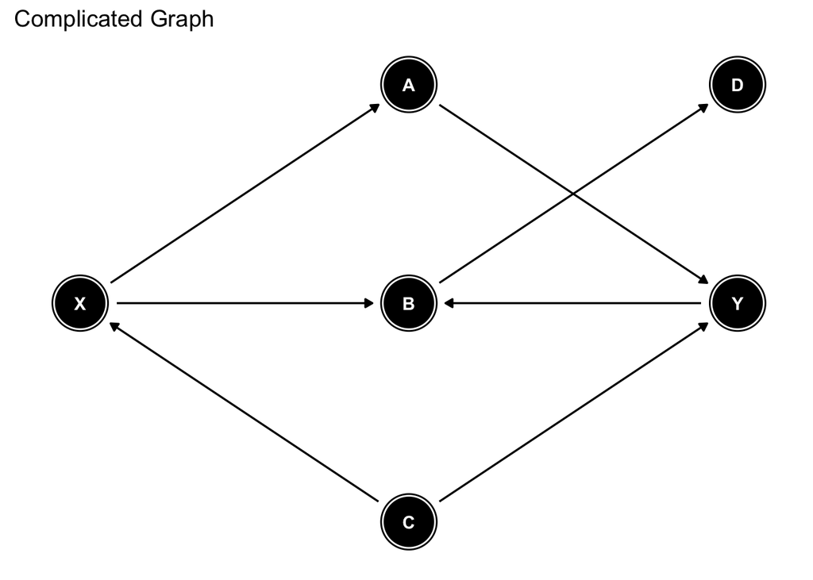

## Measuring effect of X on Y

- Go back to education $X$ versus wages $Y$ to get intuition
- $A$ caused by $X$, causes $Y$: e.g., occupation, experience
  - Mediators: descendant of $X$, so do not adjust for it
- $B$ caused by both $X$ and $Y$: e.g., current wealth or lifestyle
  - Colliders: descendant of $X$, so do not adjust for it
- $D$ caused by $B$ only: e.g. consequences of wealth
  - Descendants of collider: still causes bias when adjusted for
- $C$, causes $X$ and $Y$: e.g. ability, background
  - Confounder: must condition on it
- Backdoor criterion calculates this automatically

```r
adjustmentSets(complicatedgraph,exposure="X",outcome="Y")
```

```
##  { C }
```

## Imperfect control (Code)

```r
confoundgraph<-dagify(Y~X+W,X~W) #create graph
#Set position of nodes
coords<-list(x=c(X = 0, W = 1, Y = 2),
          y=c(X = 0, W = -0.1, Y = 0))
coords_df<-coords2df(coords)
coordinates(confoundgraph)<-coords2list(coords_df)
#Plot causal graph
ggdag(confoundgraph)+theme_dag_blank()
```

## Imperfect control

- When backdoor criterion fails, OLS will *not* generally give valid estimates of causal effect
- Why not?
  - May have unobserved causal factors influencing both Y and X
- Can see this in confounding setting

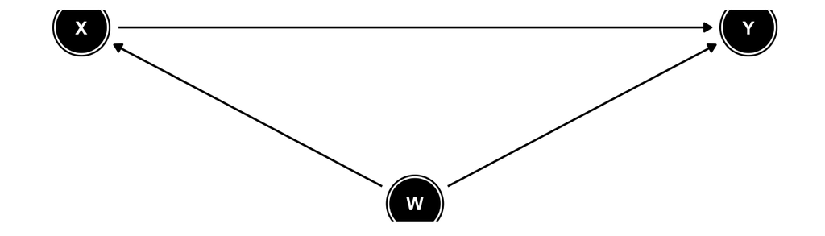

- Can recover ATE by estimating
  $$Y =\beta_0 +\beta_{1}X +\beta_{2}W + U$$
  $$E[U|X,W]=0$$

## Imperfect Control, ctd

- Suppose we don’t include $W$
  - Maybe we just forgot about it
  - Maybe it’s not something we can get data about
- If we omit $W$, regression becomes
  $$Y= \beta_0+\beta_1X +\epsilon$$
  $$\epsilon = \beta_2W+U$$
- Result is $Cov(X,\epsilon)\neq 0$
- Estimate of $\beta_1$ is biased: omitted variables bias

## Endogeneity

- General case where OLS gives inconsistent estimate of parameters
  $$Y=\mathbf{x}^\prime\beta + u$$
  $$E[\mathbf{x}u]\neq 0$$
- This is saying OLS assumption (4’) $E[\mathbf{x}u] = 0$ violated for linear model with causal coefficients
- Here $\beta$ contains true structural parameter of interest
  - $u$ NOT just difference between $Y$ and best linear predictor of $Y$
- Omitted variables are common cause of endogeneity
- OLS estimate not consistent for $\beta$

## An alternative: Instrumental variables (IV)

- Consider a simple regression with endogeneity
  $$Y=\beta_0+\beta_1X + u$$
  $$E[Xu]\neq 0$$
- We don’t have controls to add to regression to solve this
- We might have some variables $Z$ that **don’t** matter for $Y$, or at least not directly
- In particular, $Z$ affects $X$ but not $Y$
- All influence of $Z$ on $Y$ comes via effect on $X$
  - None through whatever is in $u$
- Then we may be able to find effect of $X$ by looking only at variation in $X$ which is coming through $Z$

## Goal of IV estimation

- $Z$ is randomly assigned, but $X$ isn’t
- AND $Z$ only has direct effect on $X$, not $Y$
  - The “Part of $X$ determined by $Z$” is then effectively random
- Example: Effect of going to a particular school $X$ on wages $Y$
- Admission to school determined by lottery $Z$
- Not all admitted students attend: some go to other schools
  - Reasons determined by *unobserved* personal characteristics $W$
- $X$ not random, due to missing controls
- $Z$ *is* random, uncorrelated with $W$
- We could get effect of $Z$ on $Y$, but really want effect of $X$
- IV lets us use the randomness of $Z$ to estimate effect of $X$

## Causal graph of IV model (Code)

```r
ivgraph<-dagify(Y~X+W,X~W, X~Z) #create graph
#Set position of nodes
coords<-list(x=c(X = 0, W = 1, Y = 2, Z=-1),
          y=c(X = 0, W = 0.1, Y = 0, Z=0))
coords_df<-coords2df(coords)
coordinates(ivgraph)<-coords2list(coords_df)
#Plot causal graph
ggdag(ivgraph)+theme_dag_blank()
  +labs(title="Instrumental Variables")
```

## Causal graph of IV model

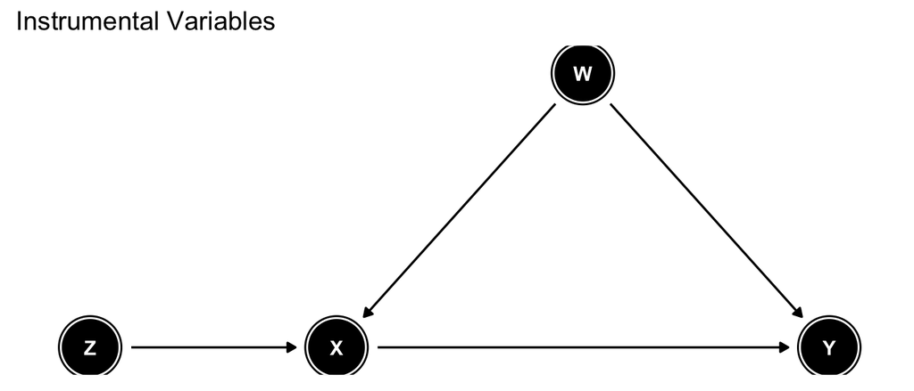

- No arrows into $Z$
  - Determined independently
- Arrow from $Z$ to $X$, but **not** to $Y$
  - Z has *direct* effect on X but *not* on Y
- If $W$ *were* observed, could use control to find effect of $X$ on $Y$
- If $W$ *not* observed, but $Z$ is, can use instrumental variables estimator

## Finding an instrument

- Instruments offen the result of a *natural experiment*
- $X$ maybe determined by many things,
  - But one of them acts effectively like an experiment
- Something like a random number generator somehow influences $X$, among other influences
- Maybe this is an actual random number generator
  - E.g. a lottery, or a coin flip
- We don’t care about effect of coin flip itself on outcome
  - Want to use it estimate effect of $X$
- E.g., *Admission* lottery for school allows us to estimate effect of *Enrollment* on outcome (like wages)
  - Even if enrollment not random
  - Determined in part by unobserved preference for school
  - Lottery has no direct effect on wages, but does affect enrollment

## Estimation in IV Model

- Let $\beta_1$ be true causal effect. Then regression equation
  $$Y=\beta_0+\beta_1X + u$$
  has
  $$E[Xu]\neq 0$$
- $X$ is called the **endogenous regressor**
- We have another variable $Z$ called the **instrument**
- It satisfies 2 conditions: **Exogeneity** and **Relevance**
- **Exogeneity**:
  $$Cov(Z,u)=0$$
- **Relevance**:
  $$Cov(Z,X)\neq 0$$
- Let’s see how these let us solve the endogeneity problem
- Then go back to see what they mean

## One more assumption

- Model
  $$Y=\beta_0+\beta_1X + u$$
- Add 1 more assumption
  $$E[u]=0$$
- Assumption is weak
  - Can always change $\beta_0$ to equal $\beta_0+E[u]$ if not true
  - If we don’t care about $\beta_0$, this is not a problem
  - IV will still let us estimate $\beta_1$

## Finding $\beta_1$ using IV

- Model
  $$Y=\beta_0+\beta_1X + u$$
- Exogeneity
  $$Cov(Z,u)=0$$
- Relevance
  $$Cov(Z,X)\neq 0$$
- Mean 0 errors
  $$E[u]=0$$

## Finding $\beta_1$

- Rewrite Assumptions using model
- Mean 0 errors
  $$E[Y-\beta_0-\beta_1X]=0$$
- Exogeneity
  $$Cov(Z,u)=E[Zu]-E[Z]E[u]=E[Zu]=0$$
- This becomes
  $$E[Z(Y-\beta_0-\beta_1X)]=0$$
- System of 2 linear equations in 2 unknowns

## Solving the system

$$E[Y-\beta_0-\beta_1X]=0$$
$$E[Z(Y-\beta_0-\beta_1X)]=0$$

- This becomes
  $$\beta_0=E[Y]-\beta_1E[X]$$
- Plug in to second equation
  $$E[Z((Y-E[Y])-\beta_1(X-E[X]))]=0$$
  $$\beta_1=\frac{E[Z(Y-E[Y])]}{E[Z(X-E[X])]}$$
  $$\beta_1=\frac{Cov(Z,Y)}{Cov(Z,X)}$$

## IV Estimator

- We just **identified** the parameter in terms of features of observable distribution
  $$\beta_1=\frac{Cov(Z,Y)}{Cov(Z,X)}$$
  $$\beta_0=E[Y]-\beta_1E[X]$$
- Suppose we have random sample of n draws of $(X_i,Y_i,Z_i)$
- We can estimate by replacing expectations with sample averages

$$\hat{\beta}_1^{IV}=\frac{\frac{1}{n}\sum_{i=1}^{n}(Z_i-\bar{Z})(Y_i-\bar{Y})}{\frac{1}{n}\sum_{i=1}^{n}(Z_i-\bar{Z})(X_i-\bar{X})}$$
$$\hat{\beta}_0^{IV}=\frac{1}{n}\sum_{i=1}^{n}Y_i-\hat{\beta}_1^{IV}\frac{1}{n}\sum_{i=1}^{n}X_i$$

## Relevance Condition

- We assumed **relevance**: $Cov(Z,X)\neq 0$
- Need this for estimator to have a solution, to define
  $$\beta_1=\frac{Cov(Z,Y)}{Cov(Z,X)}$$
- In words, instrument needs to be correlated with endogenous regressor
- This allows us to use $Z$ say something about effect of $X$

## Exclusion restriction

- We assumed **exogeneity** of $Z$: $E[Zu]=0$
- Sometimes this is called *Exclusion Restriction*
- In words, $Z$ cannot be correlated with the residual
  - Even though, by assumption, $X$ is
- Usually because $Z$ has *no* direct causal effect on $Y$
- In case of omitted variable bias, means $Z$ is uncorrelated with omitted variable
- Note difference from strategy of control:
  - To control, we want to find the omitted variable and include it
  - For IV, want something totally unrelated to omitted variable
- Idea: want to find a source of variation in $X$ which is effectively random, even if $X$ in general is determined nonrandomly

## Reduced Form and First Stage

- Total effect of $Z$ on $Y$ consistently estimable by regression
- Regression of $Y$ on $Z$ called **reduced form**
  - Slope is $\rho = Cov(Y,Z)/Var(Z)$
  - By exclusion restriction, we know this only comes indirectly, through instrument’s effect on $X$
- Effect of $Z$ on $X$ consistently estimable by regression
  - Regression of $X$ on $Z$ called **first stage**
  - Slope is $\pi = Cov(X,Z)/Var(Z)$
- IV is
  $$\beta_1=Cov(Y,Z)/Cov(X,Z)= \rho/\pi$$

## IV interpretation

- IV adjusts reduced form (quasi)experimental estimate of effect of instrument $Z$ on outcome $Y$ by amount experimental treatment actually affected $X$
- Consider 2 cases
1. First stage $\pi$ small, but total effect $\rho$ of instrument on outcome big
   - Then effect must have come from very large effect of $X$
   - $X$ didn’t move much even though outcome did
2. First stage $\pi$ big but total effect $\rho$ of instrument on outcome small
   - $X$ must have small effect
   - $X$ moved a lot with the experiment but outcome $Y$ mostly stayed the same

## Example: Effect of longer prison sentences on recidivism

- Example drawn from [Green and Winik (2010, Criminology)]
- Policy question: how long should prison sentences be?
  - Incarceration has many potential costs and benefits, need to know what they are to evaluate.
- To measure benefits, need measure of outcomes given longer or shorter sentences
- Outcome variable: $Y$
  - Measure of recidivism for people on trial for a particular crime
- Variable of interest $X$
  - Length of prison sentence given to offender
- Ideal experiment
  - Randomly assign prison sentences to criminals
  - Measure recidivism and regress on sentence length
- But this hasn’t been done
  - Would be unethical

## Endogeneity problem

- Instead, look at prison sentences assigned the usual way
  - A judge using sentencing guidelines and discretion
- Endogeneity problem
  - People assigned longer prison sentences likely differ from those given shorter sentences
  - May be more likely to be guilty,
  - Or have characteristics that make judge think they are
  - Or likely to be at risk of recidivism
- If we could include all variables influencing judge’s decision and find functional form replicating their judgment, could control for them
- This is hard:
  - Decisions include component based on perceive probability of reoffending
  - Likely to be correlated with actual reoffending
- Instead, look for instrument
  - Something affecting sentences which is random

## IV solution

- In this case, can use one random component of trials:
  - Judges assigned randomly to defendants
- Z is random judge assignment (say, to judge 1 or judge 2)
- Don’t care about effect of judge 1 vs judge 2 per se
  - Given by reduced form regression of $Y$ on $Z$
- Clear that $Z$ satisfies exogeneity: $E[Zu]=0$
  - Random choice of judge is unrelated to defendant characteristics
- $Z$ satisfies relevance $Cov[ZX]\neq0$ if 1 judge tends to give harsher sentences than the other on average for any given defendant
  - Maybe judge 2 interprets sentencing guidelines in different way, or just has different temperament or judgment
- IV finds the difference in recidivism associated with variation in sentence length due to having been randomly assigned a different judge

## IV Results

- Green and Winik find IV estimates close to 0
- Mechanically: effect of which judge one assigned to on recidivism rate is extremely small
- Dividing this effect by the difference in sentences due to the difference in judges, which was non-negligible, suggests that different sentences can’t have affected recidivism that much

## Conclusions

- Causal graph determines conditional independence relationships
  - Backdoor criterion describes when control strategy can be used to estimate treatment effect
- When proper controls not observed or included, regression coefficients have *endogeneity* bias
- Might still be able to estimate effect if data contains an **instrument**
  - An instrument is a variable which leads to variation in a treatment $X$ without directly affecting the outcome $Y$
  - With an instrument, can use instrumental variables estimator to measure treatment effect

## Next 2 classes

- More about IV
- Read Ch 15 in Wooldridge
- Read Ch 3 in Angrist and Pischke